# MUSA508-HW4-Emil City’s Home Repair Tax Credit Program

Emma Sun

10/29/2020

```r
palette5 <- c( "#ff4500",'#e3eec2'  , '#853353' ,'#2f8fb1', '#f4ac94')

palette2 <- c("#4693eb","#ffb026")

subsidy <- read.csv("/Users/penguin/Box Sync/GitHub/MUSA508-Project4-Bounce to Work/housingSubsidy.csv")

# View(subsidy)
# y.numeric = 1: take the program
# y.numeric = 0: not take the programs

# colnames(subsidy)
# table(subsidy$education)
# table(subsidy$y)
```

## I. Introduction and Motivation

When state legislators consider proposals for new economic development tax incentives, they face hard choices. Subtle differences in the design of business incentives—such as how costs and benefits are structured or how states determine which individual are eligible—can make the difference between programs that achieve their goals and ones that prove ineffective. To better facilitate Emil City’s home repair tax credit program and help the **Department of Housing and Community Development (HCD)** target their limited outreach resources, this analysis is aimed at exploring the characteristics of homeowners who potentially take advantage of the program for house maintenance, and evaluating the efficiency of the outreach campaign by conducting a cost-benefit analysis. This analysis is expected to help HCD reach out to eligible individuals as many as possible but also maximize the fiscal revenues.

## II. Exploratory Analysis: Feature Correlation

It is imperative to explore and build features that are strongly correlated to the uptake in the tax credit before building any model. This section respectively plots continuous variables and categorical variables against the uptake of the tax credit.

For the all 4,119 observations, 3,668 homeowners did not take the credit, while only 451 homeowners, accounted for only 10.95% of all homeowners reached out to HCD and took the credit.

Whether there is a lien against the owner’s property (`taxLien`), homeowners’ age (`age`), seems to have no distinct correlation with the uptake of the tax credit.

*Note: Features `age` and `pdays` are regarded as continuous variables here for better visualization though they labeled a categorical variables in the codebook provided.*

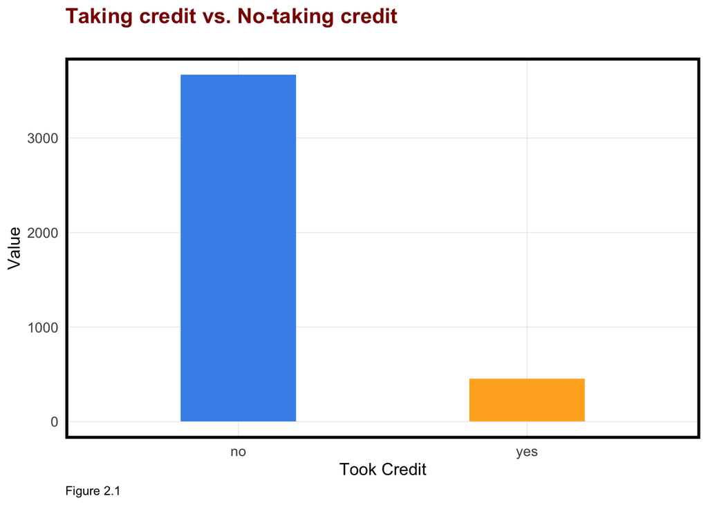

```r
ggplot(data = subsidy) +
  geom_bar(aes(y,fill = y),width = 0.4) +
          scale_fill_manual(values = palette2,
                          name = 'Took Credit') +
  labs(x="Took Credit", y="Value",
           title = "Taking credit vs. No-taking credit\n",
       caption = 'Figure 2.1') +
      theme(legend.position = "none") +
  plotTheme()
```

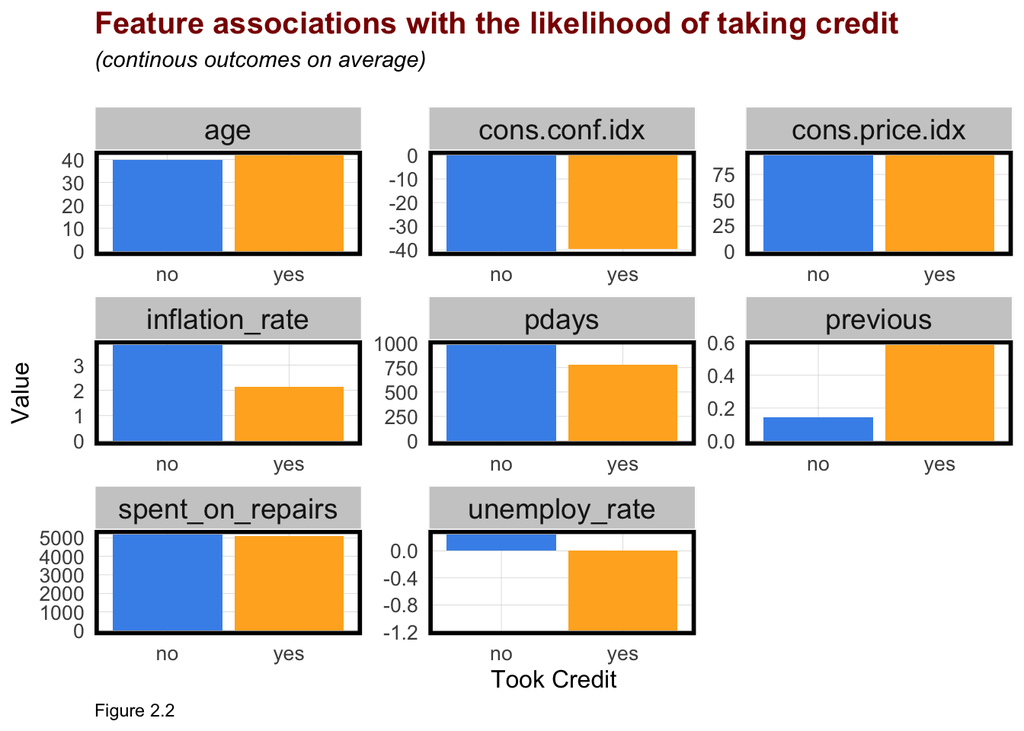

```r
subsidy %>%
  dplyr::select(y,previous, unemploy_rate,cons.price.idx,cons.conf.idx,inflation_rate, spent_on_repairs, age, pdays) %>%
  gather(Variable, value, -y) %>%
    ggplot(aes(y, value, fill=y)) +
      geom_bar(position = "dodge", stat = "summary", fun.y = "mean") +
      facet_wrap(~Variable,  scales = "free") +
        scale_fill_manual(values = palette2,
                          name = 'Took Credit') +
      labs(x="Took Credit", y="Value",
           title = "Feature associations with the likelihood of taking credit",
           subtitle = "(continous outcomes on average)\n",
       caption = 'Figure 2.2') +
      theme(legend.position = "none") +
  plotTheme()
```

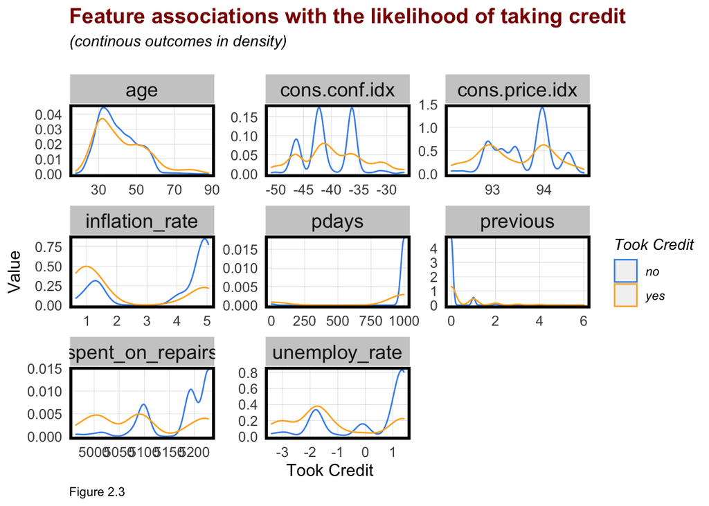

```r
subsidy %>%
  dplyr::select(y,previous, unemploy_rate,cons.price.idx,cons.conf.idx,inflation_rate, spent_on_repairs, age, pdays) %>%
    gather(Variable, value, -y) %>%
    ggplot() +
    geom_density(aes(value, color=y), fill = "transparent") +
    facet_wrap(~Variable,  scales = "free") +
        scale_color_manual(values = palette2,
                          name = 'Took Credit') +
    labs(x="Took Credit", y="Value",
           title = "Feature associations with the likelihood of taking credit",
           subtitle = "(continous outcomes in density)\n",
       caption = 'Figure 2.3') +
      theme(legend.position = "right") +
  plotTheme()
```

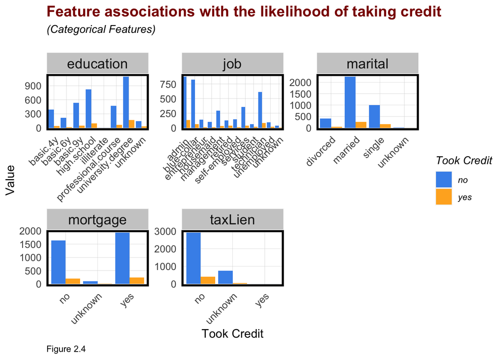

```r
subsidy %>%
    dplyr::select(y,job, marital,education,taxLien,mortgage) %>%
    gather(Variable, value, -y) %>%
    count(Variable, value, y) %>%
      ggplot(., aes(value, n, fill = y)) +
        geom_bar(position = "dodge", stat="identity") +
        facet_wrap(~Variable,  scales="free") +
        scale_fill_manual(values = palette2,
                          name = 'Took Credit') +
        labs(x="Took Credit", y="Value",
             title = "Feature associations with the likelihood of taking credit",
             subtitle = "(Categorical Features)\n",
       caption = 'Figure 2.4') +
        theme(axis.text.x = element_text(angle = 45, hjust = 1)) +
  plotTheme()
```

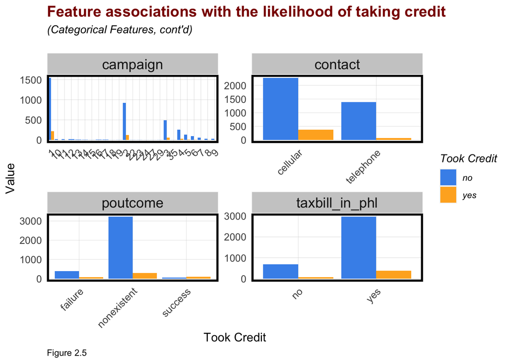

```r
subsidy %>%
    dplyr::select(y,taxbill_in_phl,contact, campaign,poutcome) %>%
    gather(Variable, value, -y) %>%
    count(Variable, value, y) %>%
      ggplot(., aes(value, n, fill = y)) +
        geom_bar(position = "dodge", stat="identity") +
        facet_wrap(~Variable,  scales="free") +
        scale_fill_manual(values = palette2,
                          name = "Took Credit") +
        labs(x="Took Credit", y="Value",
             title = "Feature associations with the likelihood of taking credit",
             subtitle = "(Categorical Features, cont'd)\n",
       caption = 'Figure 2.5') +
        theme(axis.text.x = element_text(angle = 45, hjust = 1)) +
  plotTheme()
```

## III. Initial Model Building

Since the dependent variable in this analysis is a binomial variable, this section initially builds a **Logistic Regression** model with all provided features.

*Note: Since we have detected `taxLien` is not related to the uptake of the credit, this feature is excluded from the initial model.*

### 3.1 Model Building

When building model directly with all features in the dataset, only few features are significantly related to whether an individual took the credit or not, indicting the model needs to be rebuilt by including fewer features and engineering couples of features.

*Note: Model summary will be shown together with the second model below.*

### 3.2 Predictions and Plots

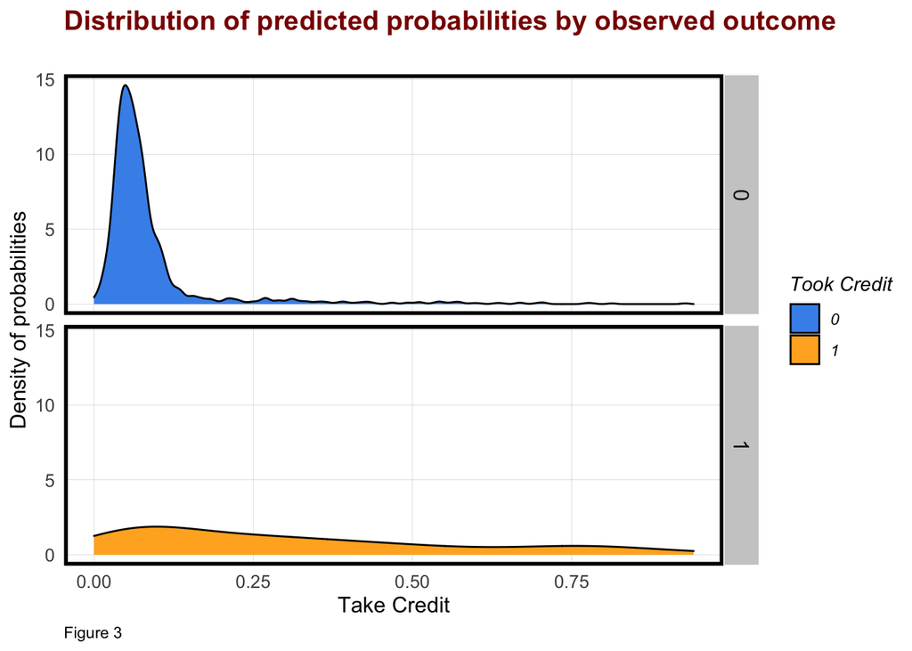

```r
# subsidyreg1$xlevels$taxLien <- union(subsidyreg1$xlevels$taxLien,
# levels(as.factor(subsidyTest$taxLien)))
testProbs1 <- data.frame(Outcome1 = as.factor(subsidyTest$y_numeric),
                        Probs1 = predict(subsidyreg1, newdata = subsidyTest, na.rm = TRUE, type= "response" ))

# glimpse(testProbs1)

ggplot(testProbs1, aes(x = Probs1, fill = as.factor(Outcome1))) +
  geom_density() +
  facet_grid(Outcome1 ~ .) +
  scale_fill_manual(values = palette2,
                    name = "Took Credit") +
  labs(x = "Take Credit", y = "Density of probabilities",
       title = "Distribution of predicted probabilities by observed outcome\n",
       caption = 'Figure 3') +
  theme(strip.text.x = element_text(size = 18),
        legend.position = "right") +
  plotTheme()
```

### 3.3 Good of Fit: Confusion Matrix

A “confusion matrix” for the threshold of 50% shows us the rate at which we got True Positives (aka Sensitivity), False Positives, True Negatives (aka Specificity) and False Negatives for that threshold.

In this case,

- True Positives: Predicted correctly homeowner would take the credit.
- False Positives: Predicted incorrectly homeowner would take the credit.
- True Negatives: Predicted correctly homeowner would not take the credit.
- False Negatives: We predicted that a homeowner would not take the credit but they did.

This analysis more cares about sensitivity since the goal is to maximize the efficiency of the outreach campaign. It is obvious that this initial model is suffering low sensitivity (*0.24204*), indicating we need to re-build the model or optimizing it!

```r
testProbs1 <-
  testProbs1 %>%
  mutate(predOutcome1  = as.factor(ifelse(testProbs1$Probs1 > 0.5 , 1, 0)))

caret::confusionMatrix(testProbs1$predOutcome1, testProbs1$Outcome1,
                       positive = "1")
```

```
## Confusion Matrix and Statistics
##
##           Reference
## Prediction    0    1
##          0 1258  119
##          1   25   38
##
##                Accuracy : 0.9
##                  95% CI : (0.8833, 0.915)
##     No Information Rate : 0.891
##     P-Value [Acc > NIR] : 0.1449
##
##                   Kappa : 0.3019
##
##  Mcnemar's Test P-Value : 0.000000000000009189
##
##             Sensitivity : 0.24204
##             Specificity : 0.98051
##          Pos Pred Value : 0.60317
##          Neg Pred Value : 0.91358
##              Prevalence : 0.10903
##          Detection Rate : 0.02639
##    Detection Prevalence : 0.04375
##       Balanced Accuracy : 0.61128
##
##        'Positive' Class : 1
##
```

## IV. Model Optimization

### 4.1 Feature Engineering

To refine the model, 1. `previous`is converted to binary variable with two levels: yes/no, saved in `precontact`. 2. `education` was simplified into five categories only (Basic, High School, Professional, University, and Others), saved in `edu.level`. 3. `pdays` is transformed into binary variable with two levels: yes/no by comparing with 7, saved in `contactInterval`. 4. Two more features `month_mar` and `month_dec` are also built to exclusively identify two reach out months.

```r
subsidy$edu.level[subsidy$education == "basic.4y" |subsidy$education == "basic.6y"|subsidy$education == "basic.9y"] <- "Basic"
subsidy$edu.level[subsidy$education == "unknown" |subsidy$education == "illiterate"] <- "Others"
subsidy$edu.level[subsidy$education == "high.school"]  <- "High School"
subsidy$edu.level[subsidy$education == "professional.course"]  <- "Professional"
subsidy$edu.level[subsidy$education == "university.degree"]  <- "University"

subsidy <- subsidy %>%
  dplyr::mutate(precontact = ifelse(previous == 0,0,1),
                contactInterval = ifelse(pdays > 7,"Long","Short"),
                month_mar = ifelse(month == "mar", "march", "other"),
                month_dec = ifelse(month == "dec", "december", "other")
                )
```

### 4.2 Model Building

The second model is built by adding features engineered above and ruling out `age`,`education`,`taxLien`,`pdays`,`previous`,`month`,`job`,`marital`.

```r
set.seed(3456)
trainIndex <- createDataPartition(subsidy$y, p = .65,
                                  list = FALSE,
                                  times = 1)
subsidyTrain <- subsidy[ trainIndex,]
subsidyTest  <- subsidy[-trainIndex,]

subsidyreg2 <- glm(y_numeric ~ .,
                  data=subsidyTrain %>%
                    dplyr::select(-X,-y,-age,-education,-taxLien,-pdays,-previous,-month,-job,-marital),
                  family="binomial" (link="logit"))


stargazer(subsidyreg1, subsidyreg2, type = "html",
          title = "Table 4. Summary Statistics of Model 1 on Training Set",
          header = FALSE,
          single.row = TRUE,
          column.labels=c("Model 1","Model 2"))
```

**Table 4. Summary Statistics of Model 1 on Training Set**

|  | *Dependent variable:* |  |
| --- | --- | --- |
|  | y_numeric |  |
|  | Model 1 | Model 2 |
|  | (1) | (2) |
| age | 0.004 (0.009) |  |
| jobblue-collar | -0.202 (0.270) |  |
| jobentrepreneur | -0.440 (0.457) |  |
| jobhousemaid | -0.608 (0.553) |  |
| jobmanagement | -0.296 (0.306) |  |
| jobretired | -0.077 (0.370) |  |
| jobself-employed | -0.720 (0.459) |  |
| jobservices | -0.379 (0.299) |  |
| jobstudent | -0.583 (0.475) |  |
| jobtechnician | -0.082 (0.233) |  |
| jobunemployed | -0.004 (0.428) |  |
| jobunknown | -0.345 (0.700) |  |
| maritalmarried | 0.003 (0.239) |  |
| maritalsingle | -0.027 (0.274) |  |
| maritalunknown | -11.795 (329.215) |  |
| educationbasic.6y | 0.367 (0.400) |  |
| educationbasic.9y | -0.075 (0.339) |  |
| educationhigh.school | 0.133 (0.323) |  |
| educationilliterate | -13.186 (882.744) |  |
| educationprofessional.course | 0.179 (0.350) |  |
| educationuniversity.degree | 0.288 (0.323) |  |
| educationunknown | 0.320 (0.413) |  |
| mortgageunknown | -0.111 (0.567) | -0.149 (0.551) |
| mortgageyes | -0.209 (0.143) | -0.191 (0.141) |
| taxbill_in_phlyes | 0.182 (0.201) | 0.166 (0.197) |
| contacttelephone | -0.642** (0.285) | -0.993*** (0.220) |
| monthaug | 0.012 (0.444) |  |
| monthdec | 1.819** (0.780) |  |
| monthjul | 0.099 (0.374) |  |
| monthjun | 0.060 (0.472) |  |
| monthmar | 1.391** (0.569) |  |
| monthmay | -0.410 (0.316) |  |
| monthnov | -0.615 (0.425) |  |
| monthoct | 0.070 (0.548) |  |
| monthsep | -0.926 (0.683) |  |
| day_of_weekmon | -0.317 (0.221) | -0.329 (0.218) |
| day_of_weekthu | -0.141 (0.215) | -0.189 (0.212) |
| day_of_weektue | -0.157 (0.217) | -0.165 (0.213) |
| day_of_weekwed | -0.205 (0.231) | -0.240 (0.227) |
| campaign | -0.108** (0.043) | -0.105** (0.043) |
| pdays | -0.001 (0.001) |  |
| previous | 0.243 (0.213) |  |
| poutcomenonexistent | 0.743** (0.350) | 0.460** (0.219) |
| poutcomesuccess | 1.110 (0.748) | 1.259** (0.594) |
| unemploy_rate | -0.939* (0.487) | -1.056*** (0.232) |
| cons.price.idx | 0.908 (0.861) | 1.750*** (0.357) |
| cons.conf.idx | 0.023 (0.029) | 0.066*** (0.021) |
| inflation_rate | 0.500 (0.448) | 0.007 (0.286) |
| spent_on_repairs | -0.004 (0.011) | 0.007 (0.005) |
| edu.levelHigh School |  | 0.126 (0.205) |
| edu.levelOthers |  | 0.308 (0.336) |
| edu.levelProfessional |  | 0.228 (0.232) |
| edu.levelUniversity |  | 0.337* (0.187) |
| precontact |  |  |
| contactIntervalShort |  | 0.653 (0.608) |
| month_marother |  | -1.877*** (0.440) |
| month_decother |  | -2.029*** (0.678) |
| Constant | -64.457 (131.587) | -193.449*** (54.178) |
| Observations | 2,679 | 2,679 |
| Log Likelihood | -744.481 | -756.667 |
| Akaike Inf. Crit. | 1,588.962 | 1,561.335 |
| *Note:* | p<0.1; p<0.05; p<0.01 |  |

### 4.3 Predictions and Plots

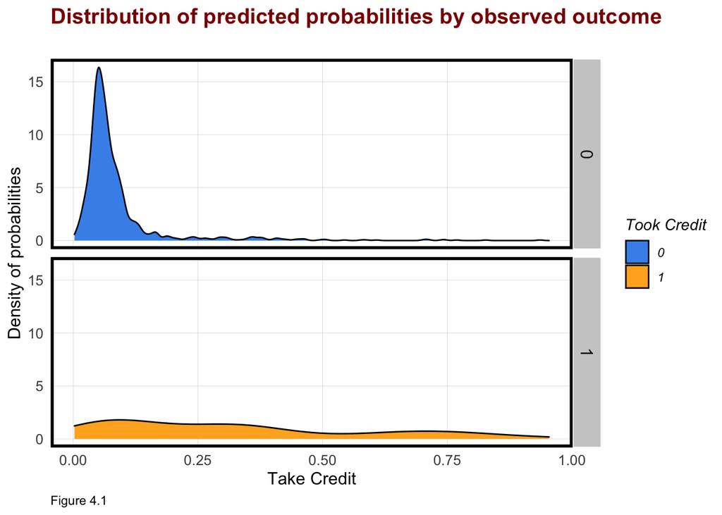

```r
testProbs2 <- data.frame(Outcome2 = as.factor(subsidyTest$y_numeric),
                        Probs2 = predict(subsidyreg2, newdata = subsidyTest, na.rm = TRUE, type= "response" ))



ggplot(testProbs2, aes(x = Probs2, fill = as.factor(Outcome2))) +
  geom_density() +
  facet_grid(Outcome2 ~ .) +
  scale_fill_manual(values = palette2,
                          name = "Took Credit") +
  labs(x = "Take Credit", y = "Density of probabilities",
       title = "Distribution of predicted probabilities by observed outcome\n",
       caption = 'Figure 4.1') +
  theme(strip.text.x = element_text(size = 18),
        legend.position = "right") +
  plotTheme()
```

### 4.4 Good of Fit: Confusion Matrix

Shown below, the sensitivity rate only improved roughly by **0.006** in the new model (from **0.24204** to **0.24841**), and the specificity, overall accuracy and kappa of the second model also slightly improved. Indicated from the high value of specificity, both models are much better at correctly predicting those who did not take the credit than those who took the credit.

```r
testProbs2 <-
  testProbs2 %>%
  mutate(predOutcome2  = as.factor(ifelse(testProbs2$Probs2 > 0.5 , 1, 0)))

caret::confusionMatrix(testProbs2$predOutcome2, testProbs2$Outcome2,
                       positive = "1")
```

```
## Confusion Matrix and Statistics
##
##           Reference
## Prediction    0    1
##          0 1269  118
##          1   14   39
##
##                Accuracy : 0.9083
##                  95% CI : (0.8922, 0.9227)
##     No Information Rate : 0.891
##     P-Value [Acc > NIR] : 0.01739
##
##                   Kappa : 0.3348
##
##  Mcnemar's Test P-Value : < 0.0000000000000002
##
##             Sensitivity : 0.24841
##             Specificity : 0.98909
##          Pos Pred Value : 0.73585
##          Neg Pred Value : 0.91492
##              Prevalence : 0.10903
##          Detection Rate : 0.02708
##    Detection Prevalence : 0.03681
##       Balanced Accuracy : 0.61875
##
##        'Positive' Class : 1
##
```

### 4.5 Cross Validation on Both Models

This section conducted cross-validation on both models. The outputs include the mean AUC, sensitivity and specificity across the 100 k-folds. Both models generalize well with regard to specificity, while neither of models generalize well with sensitivity.

```r
ctrl <- trainControl(method = "cv", number = 100, classProbs=TRUE, summaryFunction=twoClassSummary)


cvFit.reg1 <- train(y ~ ., data = subsidy %>%
                  dplyr::select(-y_numeric, -X) %>%
                  dplyr::mutate(y = ifelse(y=="no","c1.yes","c1.no")),
                method="glm", family="binomial",
                metric="ROC", trControl = ctrl)

cvFit.reg2 <- train(y ~ ., data = subsidy %>%
                  dplyr::select(-X,-y_numeric,-age,-education,-taxLien,-pdays,-previous) %>%
                  dplyr::mutate(y = ifelse(y=="no","c2.yes","c2.no")),
                method="glm", family="binomial",
                metric="ROC", trControl = ctrl)


cvFit.reg1
```

```
## Generalized Linear Model
##
## 4119 samples
##   24 predictor
##    2 classes: 'c1.no', 'c1.yes'
##
## No pre-processing
## Resampling: Cross-Validated (100 fold)
## Summary of sample sizes: 4077, 4077, 4078, 4078, 4078, 4077, ...
## Resampling results:
##
##   ROC        Sens    Spec
##   0.7691055  0.2195  0.9809009
```

```r
cvFit.reg2
```

```
## Generalized Linear Model
##
## 4119 samples
##   19 predictor
##    2 classes: 'c2.no', 'c2.yes'
##
## No pre-processing
## Resampling: Cross-Validated (100 fold)
## Summary of sample sizes: 4078, 4078, 4077, 4077, 4078, 4077, ...
## Resampling results:
##
##   ROC        Sens    Spec
##   0.7658097  0.2175  0.982545
```

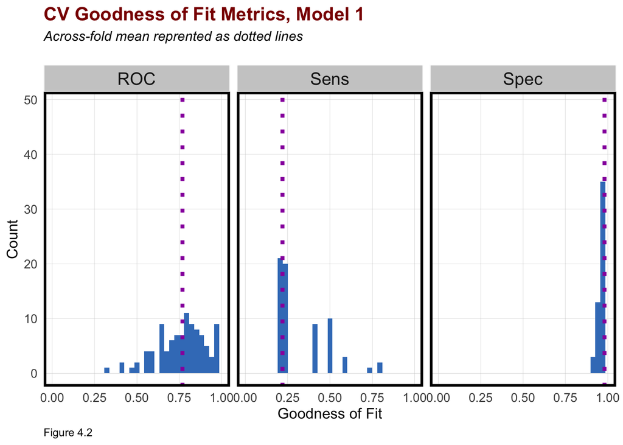

```r
dplyr::select(cvFit.reg1$resample, -Resample) %>%
  gather(metric, value) %>%
  left_join(gather(cvFit.reg1$results[2:4], metric, mean)) %>%
  ggplot(aes(value)) +
    geom_histogram(bins=35, fill = "#3e7ec2") +
    facet_wrap(~metric) +
    geom_vline(aes(xintercept = mean), colour = "#981FAC", linetype = 3, size = 1.5) +
    scale_x_continuous(limits = c(0, 1)) +
    labs(x="Goodness of Fit", y="Count",
         title="CV Goodness of Fit Metrics, Model 1",
         subtitle = "Across-fold mean reprented as dotted lines\n",
         caption = "Figure 4.2") +
  plotTheme()
```

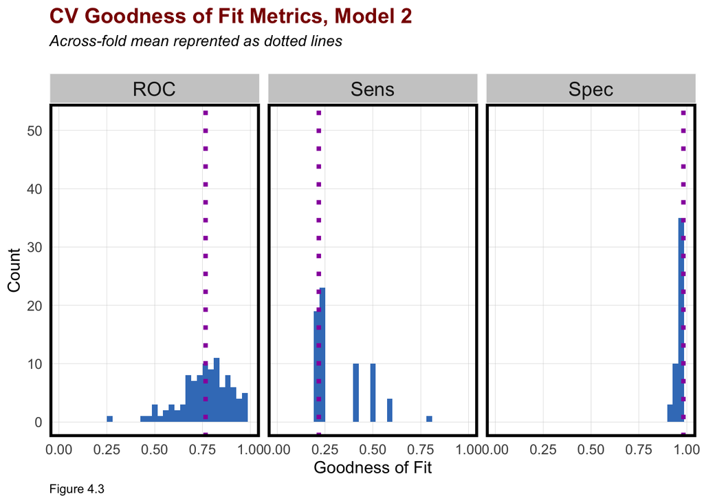

```r
dplyr::select(cvFit.reg2$resample, -Resample) %>%
  gather(metric, value) %>%
  left_join(gather(cvFit.reg2$results[2:4], metric, mean)) %>%
  ggplot(aes(value)) +
    geom_histogram(bins=35, fill = "#3e7ec2") +
    facet_wrap(~metric) +
    geom_vline(aes(xintercept = mean), colour = "#981FAC", linetype = 3, size = 1.5) +
    scale_x_continuous(limits = c(0, 1)) +
    labs(x="Goodness of Fit", y="Count",
         title="CV Goodness of Fit Metrics, Model 2",
         subtitle = "Across-fold mean reprented as dotted lines\n",
         caption = "Figure 4.3") +
    plotTheme()
```

## V. ROC Curve for New Model

Theoretically, the ROC curve indicates a TP vs. FP rate at one certain decision threshold, while AUC provides an aggregate measure of performance across all possible classification thresholds. Shown in the graph below, for every additional improvement in true positive rate, the model will make a greater proportion of false positive errors. Moving from a 75% to a 90% true positive rate dramatically increases the false positive rate. The trade-off has been triggered by such diminishing. The AUC of 0.8145 indicates that for the sake of ranking a random positive example more highly than a random negative example, this model need to set the threshold no less than 0.8145.

```r
auc(testProbs2$Outcome2, testProbs2$Probs2)
```

```
## Area under the curve: 0.8145
```

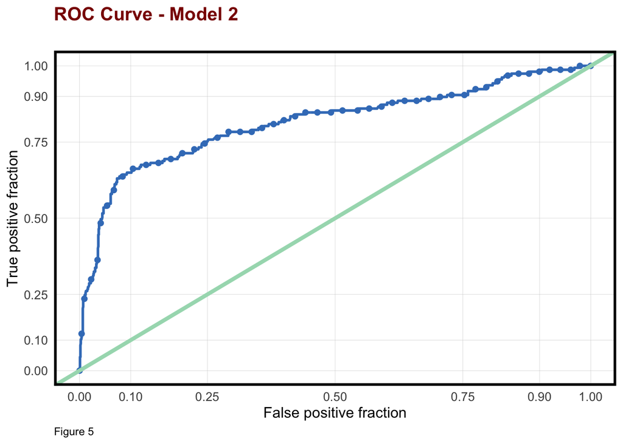

```r
ggplot(testProbs2, aes(d = as.numeric(testProbs2$Outcome2), m = Probs2)) +
  geom_roc(n.cuts = 50, labels = FALSE, colour = "#3e7ec2") +
  style_roc(theme = theme_grey) +
  geom_abline(slope = 1, intercept = 0, size = 1.5, color = '#a6dbbc') +
  labs(title = "ROC Curve - Model 2\n",
       caption = 'Figure 5') +
  plotTheme()
```

## VI. Cost-Benefit Analysis

As indicated in the very beginning, the cost-benefit analysis conducted for the public department is different from private company; rather than only care about revenue, public department cares more about the efficiency, equity and adequacy. As for this case, the cost for the HCD is generated from the campaign and allocation. On the other hand, both the homeowner’s property increase and surrounding homeowners’property increases (this analysis supposes the tax rate is 8%) are included as sources of revenue of the HCD which promotes property values increase by implementing the tax credit program.

Initially when setting the threshold up to 0.5 by default, only **157** (TP 39 and FN 118) individuals are expected to take the tax credit, of which 118 individuals might take the credit due to other reasons rather than attracted by the campaign. Under such circumstances, the HCD gains no revunue but turns out with a large amount of deficits.

### 6.1 Cost/Benefit Equation

- True Positive - Predicted correctly homeowner would take the credit; allocated the marketing resources, and 25% took the credit: `-$5000 - $2850 + ($10,000 + $56,000) * 0.08` return for 25% of cases that take credit, but only `$2850` lose for 75% of cases receive the marketing allocation but do not take the credit.
- True Negative - Predicted correctly homeowner would not take the credit, no marketing resources were allocated, and no credit was allocated: `$0`.
- False Positive - Predicted incorrectly homeowner would take the credit; allocated marketing resources; no credit allocated: `- $2850`
- False Negative - We predicted that a homeowner would not take the credit but they did. These are likely homeowners who signed up for reasons unrelated to the marketing campaign. Thus, we ‘0 out’ this category, assuming the cost/benefit of this is $0.

### 6.2 Create the “Cost/Benefit Table”

The table below indicates the count and the revenue of the four categories under the default threshold of 0.5. Optimizing the threshold might generate a higher overall revenue.

```r
cost_benefit_table <-
   testProbs2 %>%
      count(predOutcome2, Outcome2) %>%
      summarize(True_Negative = sum(n[predOutcome2==0 & Outcome2==0]),
                True_Positive = sum(n[predOutcome2==1 & Outcome2==1]),
                False_Negative = sum(n[predOutcome2==0 & Outcome2==1]),
                False_Positive = sum(n[predOutcome2==1 & Outcome2==0])) %>%
       gather(Variable, Count) %>%
       mutate(Revenue =
               ifelse(Variable == "True_Negative", 0 *Count,
               ifelse(Variable == "True_Positive",((-5000 - 2850 + (10000 + 56000) * 0.08) * Count * 0.25 +
                                                    (- 2850) * Count * 0.75),
               ifelse(Variable == "False_Negative", 0 * Count,
               ifelse(Variable == "False_Positive", (- 2850) * Count, 0))))) %>%
    bind_cols(data.frame(Description = c(
              "Predicted correctly homeowner would not take the credit",
              "Predicted correctly homeowner would take the credit",
              "Predicted incorrectly homeowner would not take the credit",
              "Predicted incorrectly homeowner would take the credit")))


kable(cost_benefit_table) %>%
  kable_styling(font_size = 12, full_width = F,
                bootstrap_options = c("striped", "hover", "condensed")) %>%
  footnote(general = "Table 6.1 Cost/Benefit Table\n",
           general_title= '\n')
```

| Variable | Count | Revenue | Description |
| --- | --- | --- | --- |
| True_Negative | 1269 | 0 | Predicted correctly homeowner would not take the credit |
| True_Positive | 39 | -108420 | Predicted correctly homeowner would take the credit |
| False_Negative | 118 | 0 | Predicted incorrectly homeowner would not take the credit |
| False_Positive | 14 | -39900 | Predicted incorrectly homeowner would take the credit |

Table 6.1 Cost/Benefit Table

### 6.3 Optimize Thresholds

This section selects optimal thresholds by plot the confusion metric outcomes for each threshold. Graphs below indicate that with the increase of the threshold, the revenues gradually increase and non-uptake prediction increases as well. However, as indicated before, maximizing the revenues is not the ultimate goal of the HCD; instead, the HCD is looking forward to allocating more credits for the sake of better development. To some extent, this model fails to achieve the objective to the HCD.

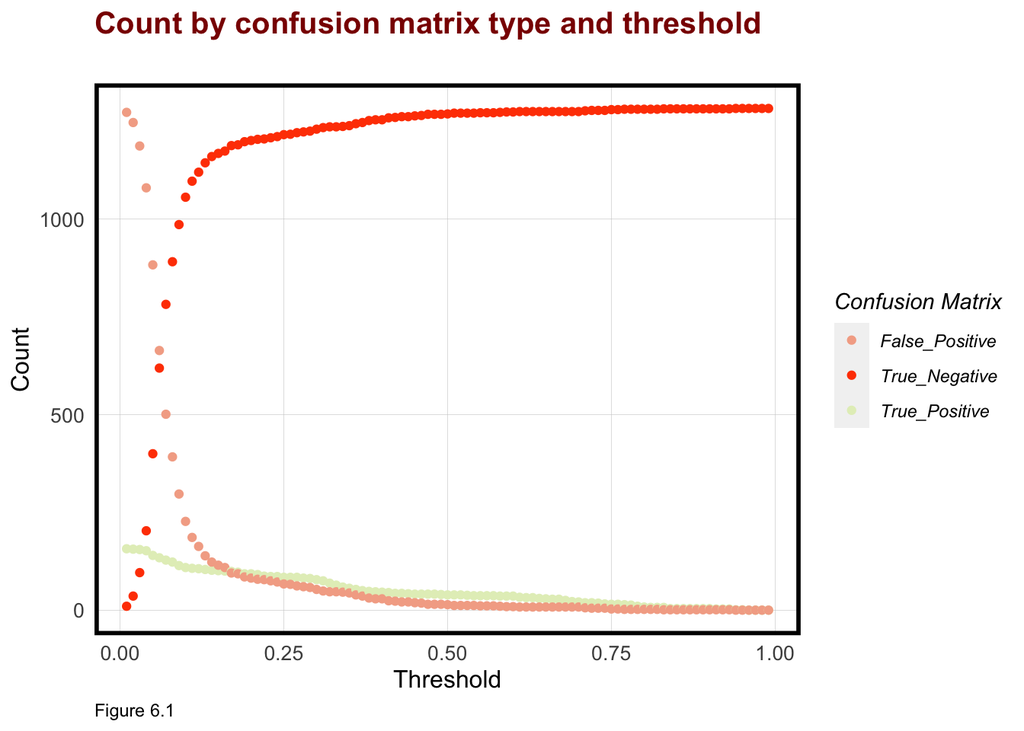

```r
iterateThresholds <- function(data) {
  x = .01
  all_prediction <- data.frame()
  while (x <= 1) {

  this_prediction <-
      testProbs2 %>%
      mutate(predOutcome2 = ifelse(Probs2 > x, 1, 0)) %>%
      count(predOutcome2, Outcome2) %>%
      summarize(True_Negative = sum(n[predOutcome2==0 & Outcome2==0]),
                True_Positive = sum(n[predOutcome2==1 & Outcome2==1]),
                False_Negative = sum(n[predOutcome2==0 & Outcome2==1]),
                False_Positive = sum(n[predOutcome2==1 & Outcome2==0])) %>%
     gather(Variable, Count) %>%
     mutate(Revenue =
               ifelse(Variable == "True_Negative", Count,
               ifelse(Variable == "True_Positive",((-5000 - 2850 + (10000 + 56000) * 0.08) * Count * 0.25 +
                                                    (- 2850) * Count * 0.75),
               ifelse(Variable == "False_Negative", 0 * Count,
               ifelse(Variable == "False_Positive", (- 2850) * Count, 0)))),
            Threshold = x)

  all_prediction <- rbind(all_prediction, this_prediction)
  x <- x + .01
  }
return(all_prediction)
}


whichThreshold_subsidy <- iterateThresholds(testProbs2)

whichThreshold_subsidy_revenue <-
whichThreshold_subsidy %>%
    group_by(Threshold) %>%
    summarize(Revenue = sum(Revenue))

whichThreshold_subsidy  %>%
  filter(Variable != 'False_Negative') %>%
  ggplot(.,aes(Threshold, Count, colour = Variable)) +
  geom_point() +
  scale_colour_manual(values = palette5[c(5, 1:3)]) +
  labs(title = "Count by confusion matrix type and threshold\n",
       y = "Count",
       caption = 'Figure 6.1') +
  plotTheme() +
  guides(colour=guide_legend(title = "Confusion Matrix"))
```

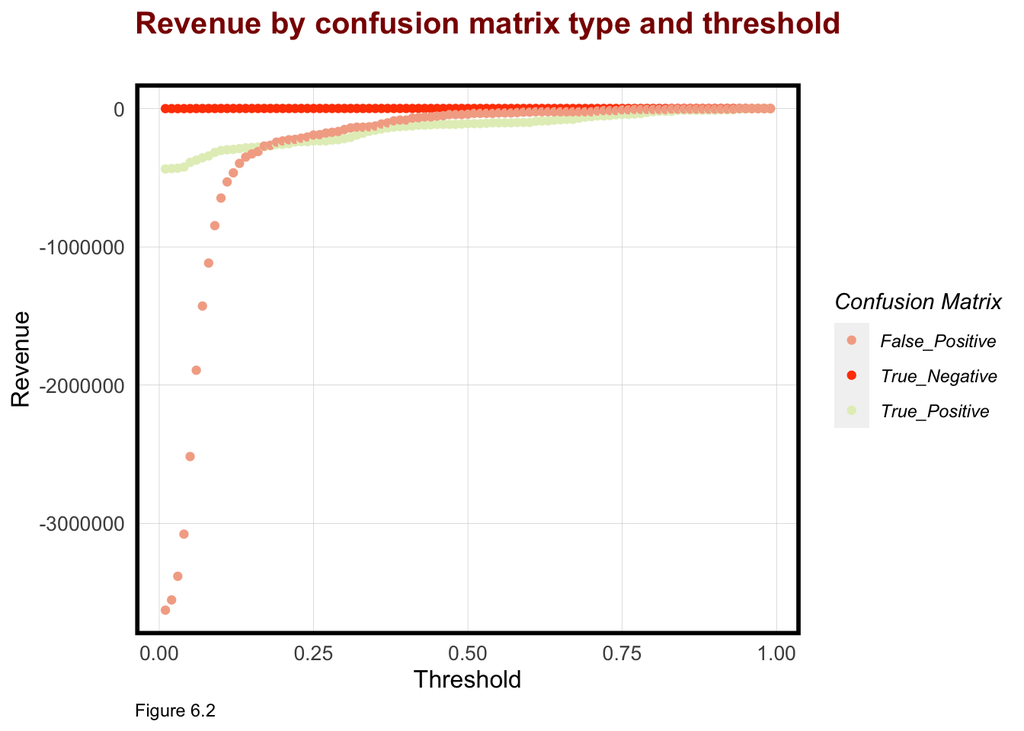

```r
whichThreshold_subsidy  %>%
  filter(Variable != 'False_Negative') %>%
  ggplot(.,aes(Threshold, Revenue, colour = Variable)) +
  geom_point() +
  scale_colour_manual(values = palette5[c(5, 1:3)]) +
  labs(title = "Revenue by confusion matrix type and threshold\n",
       y = "Revenue",
       caption = 'Figure 6.2') +
  plotTheme() +
  guides(colour=guide_legend(title = "Confusion Matrix"))
```

### 6.4 Optimum Threshold and Prediction Outcome

The two plots below indicate the total revenues and the total credit counts for each threshold in relation to the optimum threshold. It is obvious that with the increase of the threshold, both revenues and counts of credits increase.

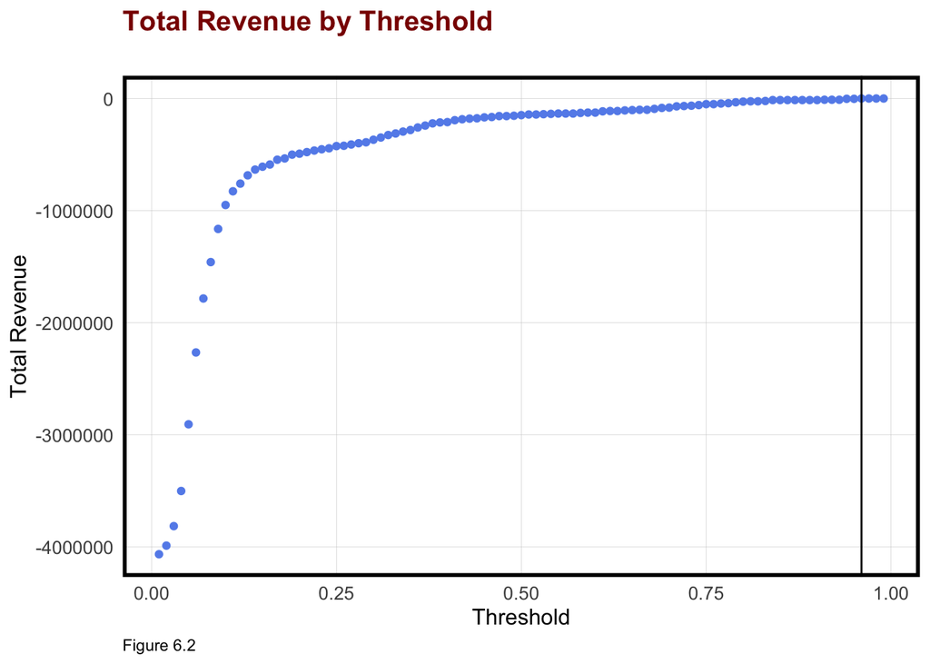

```r
whichThreshold_subsidy_revenue <-
  whichThreshold_subsidy %>%
    mutate(total_count =
               ifelse(Variable == "True_Positive", Count * 0.25,
               ifelse(Variable == 'False_Negative', Count ,0 ))) %>%
    group_by(Threshold) %>%
    summarize(Total_Revenue = sum(Revenue),
              Total_Count_of_Credits = sum(total_count))

whichThreshold_subsidy_revenue %>%
  dplyr::select(Threshold, Total_Revenue) %>%
  ggplot(aes(Threshold, Total_Revenue)) +
    geom_point(color =  "#658feb") +
    geom_vline(xintercept = pull(arrange(whichThreshold_subsidy_revenue, -Total_Revenue)[1,1])) +
  ylab('Total Revenue')  +
    plotTheme() +
    labs(title = "Total Revenue by Threshold\n",
         caption = 'Figure 6.2')
```

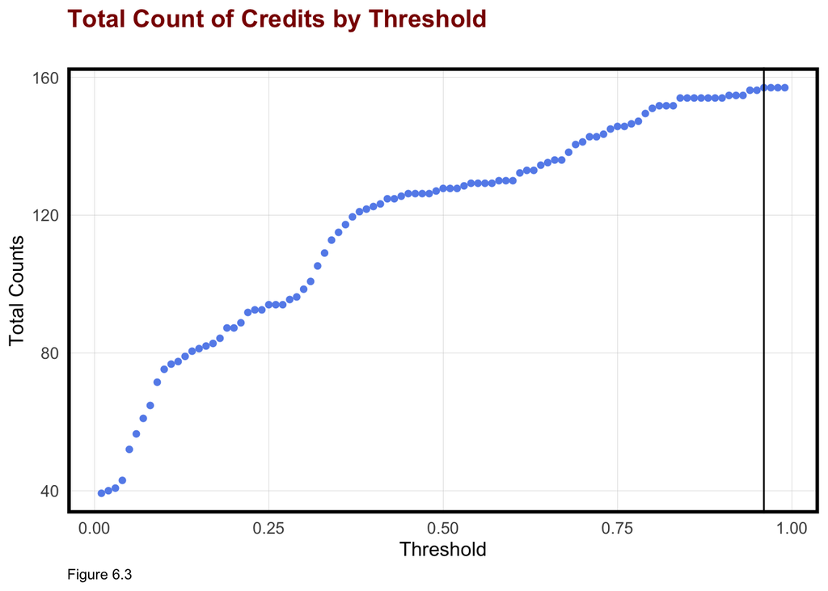

```r
whichThreshold_subsidy_revenue %>%
  dplyr::select(Threshold, Total_Count_of_Credits, Total_Revenue) %>%
  ggplot(aes(Threshold, Total_Count_of_Credits)) +
    geom_point(color =  "#658feb") +
    geom_vline(xintercept = pull(arrange(whichThreshold_subsidy_revenue, -Total_Revenue)[1,1])) +
  ylab('Total Counts')  +
  labs(title = "Total Count of Credits by Threshold\n",
       caption = 'Figure 6.3')  +
 plotTheme()
```

```r
output_table <- rbind(whichThreshold_subsidy_revenue[50,],whichThreshold_subsidy_revenue[85,])


kable(output_table) %>%
  kable_styling(font_size = 12, full_width = F,
                bootstrap_options = c("striped", "hover", "condensed")) %>%
  footnote(general = "Table 6.2 Total Revenue and Credit by Threshold\n",
           general_title= '\n')
```

| Threshold | Total_Revenue | Total_Count_of_Credits |
| --- | --- | --- |
| 0.50 | -147051 | 127.75 |
| 0.85 | -12688 | 154.00 |

Table 6.2 Total Revenue and Credit by Threshold

## VII. Conclusion

Despite efforts of features buildings, model optimization, as well as threshold optimization, it is a pity to admit that this final model should not be put into production as an approach for the HCD of targeting homeowners and weighing the costs and benefits associated with HCD’s home repair tax credit program. One of the biggest disadvantages of this model is it fails to generate high level of true positive cases that has been indicated by the unsatisfactory performance on sensitivity. To some degree, this can be accounted for by complaining about the imperfect of original data since there are far more observations who did not take the credit before rather than the opposite one.

Accordingly, how to improve model’s capacity of predicting true positive observations is the core concern to be addressed for the sake of model improvement. Given to the limited information we have had so far, it is hard to capture the characteristics of the homeowners comprehensively. More data relative to homeowners’ profiles would be much helpful.

Additionally, it is worth conducting series of surveys among the individuals who previously were reached out to but determined not to take the credits. Questions can be whether they are satisfied the campaign approach; whether the amount of $5,000 is enough or not and etc. How they react to this program would be much helpful for data analyst and policy makers to improve prediction model and modify the campaign tactics.